# vignette msqrobPTM with non-enriched DF

```r
knitr::opts_chunk$set(echo = TRUE)
knitr::opts_knit$set(root.dir = "C:/Users/Nina/OneDrive - UGent/Documenten/Doctoraat/msqrobPTM paper/vignette/")
```

```r
library(QFeatures)
library(msqrob2)
library(tidyverse)
library(gt)
library(plotly)
library(stageR)
library(poolr)
library(RColorBrewer)
library(seqinr)
library(stringr)
library(ExploreModelMatrix)
library(data.table)
```

# 1 Import data

Here we have MaxQuant output, we will work with the evidence file. Any output of a search engine/quantification algorithm that contains the MS2 intensities of every peptidoform or psm per sample can be used here.

## 1.1 Enriched dataset

```r
df <- read.csv("evidence.txt",header=TRUE)
#filter out internal standard proteins that were present in this dataset
df <- df %>% filter(!grepl("Sigma", df$Proteins))
#filter out phospho sites with less than 75% probability (optional)
filter_rows <- sapply(df$Phospho..STY..Probabilities, function(x){
  if (!x==""){
    prob <- str_extract_all(x,  "(?<=\\().+?(?=\\))")[[1]]
    if (!any(as.double(prob) > 0.75)){return(which(df$Phospho..STY..Probabilities == x))}
  }
}, USE.NAMES = F)
filter_rows <- unique(unlist(filter_rows))
nrow(df)
```

```
## [1] 33233
```

```r
df <- df[-filter_rows,]
nrow(df)
```

```
## [1] 31816
```

```r
#transorm dataframe into wide format for input into QFeatures
#We need at least information about the pepform sequence, modifications, parent protein and intensity values
df_wide <- pivot_wider(df, id_cols = c("Sequence", "Modifications", "Modified.sequence", "Proteins", "Leading.proteins",
                                        "Reverse", "Potential.contaminant", "Protein.group.IDs", "Leading.razor.protein"),
                       names_from = "Raw.file", names_prefix = "Intensity_", values_from = "Intensity", values_fn = max)
```

```r
#get columns which contain the intensity values
ecols <- grep("Intensity",colnames(df_wide))
#order dataframe by protein, for the normalisation step
df_wide = df_wide[order(df_wide$Leading.razor.protein),]
#We work with the QFeatures infrastructure, so convert dataset into a QFeatures object
#ecols = intensity columns
pe <- readQFeatures(df_wide,ecol= ecols,name="peptidoformRaw", fnames = "Modified.sequence")
```

## 1.2 Experimental Layout

We need to add information about the experimental design into the QFeatures object. In this example, this information is present in an excel file.

```r
metadata <- read.csv("metadata.csv", sep = ";")
```

We then fill out the colData of the QFeatures object by extracting this information from the file we just read in. This will later be used when doing the statistical modeling.

```r
colData(pe)$file <- sapply(str_split(rownames(colData(pe)), "_"), function(x) x[[2]])
rownames(metadata) <- metadata$Sample
colData(pe)$condition <- sapply(metadata[colData(pe)$file,]$Condition, function(x)
  ifelse(grepl("A", x), "A", "B"))
colData(pe)$subset <- metadata[colData(pe)$file,]$Subset
colData(pe)
```

```
## DataFrame with 16 rows and 3 columns
##                            file   condition      subset
##                     <character> <character> <character>
## Intensity_QX21562GM   QX21562GM           A           x
## Intensity_QX21586GM   QX21586GM           A           x
## Intensity_QX21466GM   QX21466GM           B           y
## Intensity_QX21496GM   QX21496GM           A           y
## Intensity_QX21553GM   QX21553GM           B           x
## ...                         ...         ...         ...
## Intensity_QX21463GM   QX21463GM           A           x
## Intensity_QX21717GM   QX21717GM           B           x
## Intensity_QX21511GM   QX21511GM           B           x
## Intensity_QX21520GM   QX21520GM           A           x
## Intensity_QX21782GM   QX21782GM           A           y
```

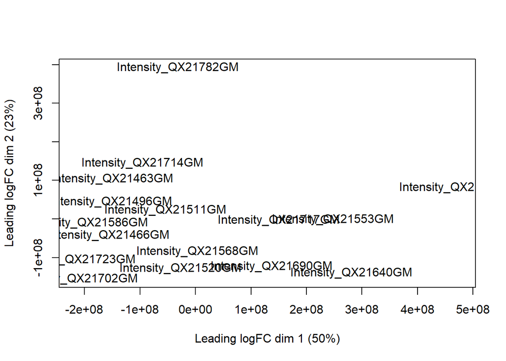

```r
limma::plotMDS(df_wide[,ecols])
```

## 1.3 Protein dataset

Here we also have a counterpart non-enriched dataset This dataset also needs to go through the data read-in and preprocessing steps

```r
df_prot <- read.csv("evidence_non_enriched.txt",header=TRUE)
#The pool samples can be ignored (those were just used for QC purposes),
#as wel as the internal standard proteins
df_prot <- df_prot %>% filter(!grepl("Pool", df_prot$Experiment),
                    !grepl("Sigma", df_prot$Proteins))

#Now get dataframe into wide format
df_prot_wide <- pivot_wider(df_prot, id_cols = c("Sequence", "Modifications", "Modified.sequence", "Proteins", "Leading.proteins",
                                        "Reverse", "Potential.contaminant", "Protein.group.IDs", "Leading.razor.protein"),
                       names_from = "Raw.file", names_prefix = "Intensity_", values_from = "Intensity", values_fn = max)
ecols <- grep("Intensity",colnames(df_prot_wide))
```

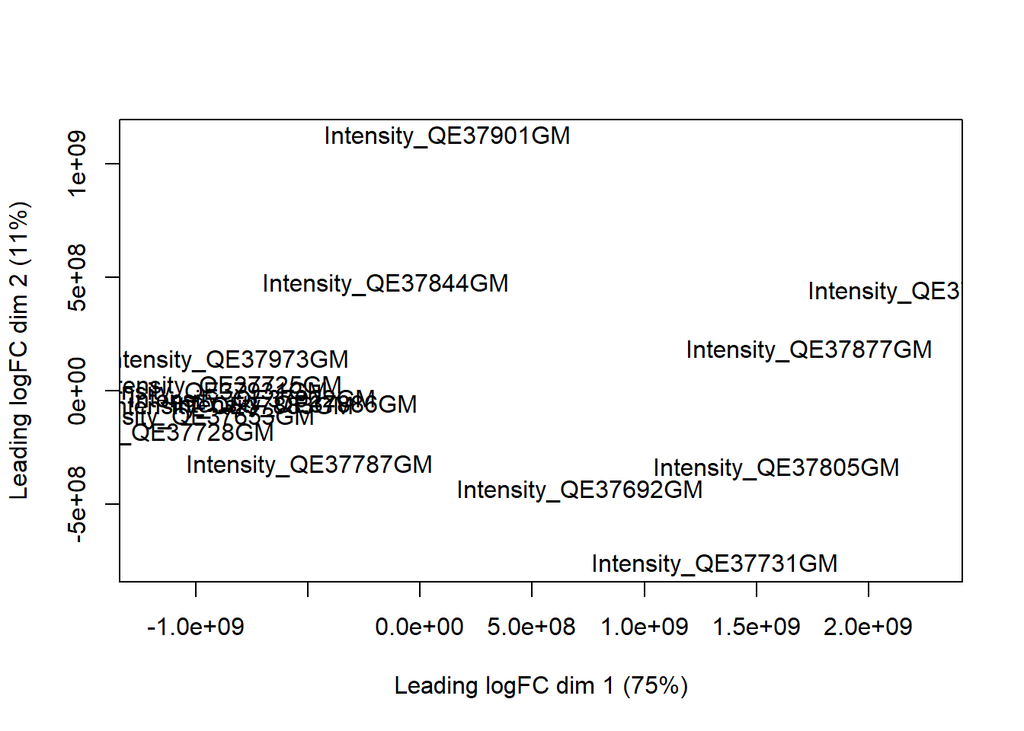

```r
limma::plotMDS(df_prot_wide[,ecols])
```

```r
#order dataframe by protein, for the normalisation step
df_prot_wide = df_prot_wide[order(df_prot_wide$Leading.razor.protein),]
prot <- readQFeatures(df_prot_wide,ecol= ecols,name="proteinRaw")
```

### 1.3.1 Experimental Layout

We need to add information about the experimental design into the QFeatures object. In this example, this information is present in an excel file.

```r
metadata <- read.csv("metadata_non_enriched.csv", sep = ";")
```

We then fill out the colData of the QFeatures object by extracting this information from the file we just read in. This will later be used when doing the statistical modeling.

```r
colData(prot)$file <- sapply(str_split(rownames(colData(prot)), "_"), function(x) x[[2]])
rownames(metadata) <- metadata$Sample
colData(prot)$condition <- sapply(metadata[colData(prot)$file,]$Condition, function(x)
  ifelse(grepl("A", x), "A", "B"))
colData(prot)$subset <- metadata[colData(prot)$file,]$Subset
colData(prot)
```

```
## DataFrame with 16 rows and 3 columns
##                            file   condition      subset
##                     <character> <character> <character>
## Intensity_QE37883GM   QE37883GM           A           x
## Intensity_QE37886GM   QE37886GM           A           y
## Intensity_QE37653GM   QE37653GM           B           y
## Intensity_QE37725GM   QE37725GM           B           x
## Intensity_QE37922GM   QE37922GM           A           x
## ...                         ...         ...         ...
## Intensity_QE37874GM   QE37874GM           A           x
## Intensity_QE37877GM   QE37877GM           B           x
## Intensity_QE37901GM   QE37901GM           A           x
## Intensity_QE37931GM   QE37931GM           B           x
## Intensity_QE37973GM   QE37973GM           B           x
```

# 2 Preprocessing

This can be adapted according to your dataset needs

## 2.1 PTM dataset

```r
rowData(pe[["peptidoformRaw"]])$nNonZero <- rowSums(assay(pe[["peptidoformRaw"]]) > 0, na.rm = T)
pe <- zeroIsNA(pe, i = "peptidoformRaw")
pe <- filterFeatures(pe, ~Reverse != "+")
pe <- filterFeatures(pe, ~Potential.contaminant != "+")
pe <- pe[rowData(pe[["peptidoformRaw"]])$nNonZero>2,,]
pe <- logTransform(pe, base = 2, i = "peptidoformRaw", name = "peptidoformLog")
pe <- normalize(pe, method = "center.median", i = "peptidoformLog", name = "peptidoform")
colData(pe[["peptidoform"]]) <- colData(pe)
```

## 2.2 Protein dataset

```r
rowData(prot[["proteinRaw"]])$nNonZero <- rowSums(assay(prot[["proteinRaw"]]) > 0, na.rm = T)
prot <- zeroIsNA(prot, i = "proteinRaw")
prot <- filterFeatures(prot, ~Reverse != "+")
prot <- filterFeatures(prot, ~Potential.contaminant != "+")
prot <- prot[rowData(prot[["proteinRaw"]])$nNonZero>2,,]
prot <- logTransform(prot, base = 2, i = "proteinRaw", name = "proteinLog")
prot <- normalize(prot, method = "center.median", i = "proteinLog", name = "protein")
colData(prot[["protein"]]) <- colData(prot)
```

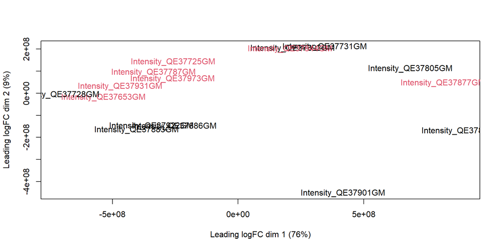

```r
limma::plotMDS(assay(prot[["proteinRaw"]]), col = as.numeric(as.factor(colData(prot)$condition)))
```

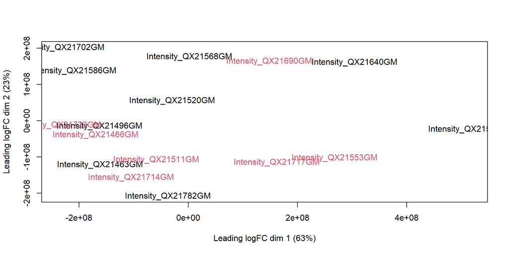

```r
limma::plotMDS(assay(pe[["peptidoformRaw"]]), col = as.numeric(as.factor(colData(pe)$condition)))
```

## 2.3 Normalisation via robust summarisation

We will now perform a normalisation of the peptidoform values. For this, we need the summarised intensity values for every protein present in the dataset, which we obtain by using the aggregateFeatures function. This function takes all peptidoforms from one protein and summarises its intensity values into one intensity value per sample for that protein. Here, the funtion with which it does this is the robustSummary function from the MsCoreUtils package which utilises robust regression.

```r
prot <- aggregateFeatures(prot,
 i = "protein",
 fcol = "Leading.razor.protein",
 na.rm = TRUE,
 name = "proteinRobust",
 fun = MsCoreUtils::robustSummary)
```

```
## Your quantitative data contain missing values. Please read the relevant
## section(s) in the aggregateFeatures manual page regarding the effects
## of missing values on data aggregation.
```

For the normalisation step, both ptm and protein dataset need to same column names for the abundance columns. If this is not already the case, corresponding samples need to be given the same name. The following code block will give everything the same name, but ideally, this should already be the case.

```r
#get current protein colnames without "Intensity_"
current_colnames <- sapply(strsplit(colnames(assay(prot[["proteinRobust"]])), "_"), function(x) x[[2]])
#replace with corresponding ptm colnames
colnames(assay(prot[["proteinRobust"]], withDimnames = F)) <-
  sapply(current_colnames, function(x){
                  ptm_colname <- metadata[metadata[["Sample"]]==x,]$`PTM.sample`
                  paste0("Intensity_", ptm_colname)
                }, USE.NAMES = F)
```

We then use these intensity values for each protein to normalise our dataframe. For each peptidoform, from their corresponding intensity values, the summarised parent protein intensity value (per sample) is subtracted.

```r
#Only take pepforms that have a parent protein
#(when there is no global profiling dataset, this will be all peptidoforms)
pepWithProtein <- rowData(pe[["peptidoform"]])$Leading.razor.protein %in% rownames(prot[["proteinRobust"]])
pePepWithProtein  <- pe[["peptidoform"]][pepWithProtein,]
pe <- addAssay(pe,pePepWithProtein,"pepformRel")
#normalisation for protein abundance step
assay(pe[["pepformRel"]]) <- assay(pe[["pepformRel"]]) - assay(prot[["proteinRobust"]],
                                                               withDimnames = F)[rowData(pe[["pepformRel"]])$Leading.razor.protein,colnames(assay(pe[["pepformRel"]]))]
```

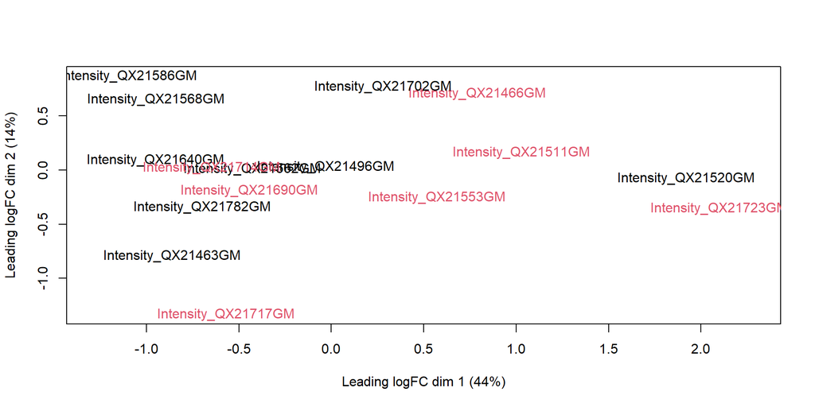

```r
limma::plotMDS(assay(pe[["pepformRel"]]), col = as.numeric(as.factor(colData(pe)$condition)))
```

# 3 Differential peptidoform usage (DPFU)

Modelling and statistical inference step on peptidoform level: we check whether there are differentially used peptidoforms present.

## 3.1 Hypothesistest for each contrast

We model the peptidoform level expression values using msqrob. By default msqrob2 estimates the model parameters using robust regression.

We will model the data with the groups incoded in the colData. We want to know whether there is difference in peptidoform usage between condition A and B and whether that difference is different for the different subsets. We can specify this model by using a formula with the factor ‘condition’ and ‘subset’ as its predictors: formula = ~condition*subset. Note that we include the interaction effect by using an asterisk in the formula. Also note that a formula always starts with a tilde ‘~’.

```r
#We specify at least the object, the assay and the formula in the function
pe <- msqrob2::msqrob(object = pe, i = "pepformRel", formula = ~condition*subset, robust=FALSE)
#We want to see the parameter names of the model
rowData(pe[["pepformRel"]])$msqrobModels[[3]] %>%
                  getCoef
```

```
##        (Intercept)         conditionB            subsety conditionB:subsety
##          1.8781986          0.5921646         -1.3228576         -0.6081688
```

conditionA is the reference class for condition and subset x is the reference class for subset, so the mean log2 expression for samples from condition A and subset x is ‘(Intercept)’. The mean log2 expression for subset x samples from condition B is’(Intercept)+conditionB’. Hence, the average log2 fold change between condition A and condition B for samples from subset x is modeled using the parameter ‘conditionB’. Thus, we assess the contrast ‘conditionB=0’ with our statistical test. The average log2 fold change between conditionA and conditionB for samples from subset y is modeled using the parameter ‘conditionB + conditionB:subsety’. Thus, we assess the contrast ‘conditionB + conditionB:subsety=0’ with our statistical test The difference between abovementioned contrasts is modeled using the interaction parameter: conditionB:subsety We can also assess an average contrast to see the average difference between condition A and B across subsets: conditionB + 0.5 * conditionB:subsety = 0

```r
contrasts <- c("conditionB", "conditionB + conditionB:subsety", "conditionB:subsety", "conditionB + 0.5 * conditionB:subsety")
L <- makeContrast(c("conditionB = 0",
                    "conditionB + conditionB:subsety = 0",
                    "conditionB:subsety = 0",
                    "conditionB + 0.5 * conditionB:subsety = 0"),
                  parameterNames = rowData(pe[["pepformRel"]])$msqrobModels[[3]] %>%
                  getCoef %>%
                  names)
#the default multiple testing correction is Benjamini Hochberg FDR correction
pe <- hypothesisTest(object = pe, i = "pepformRel", contrast = L)
```

### 3.1.1 Volcanoplot

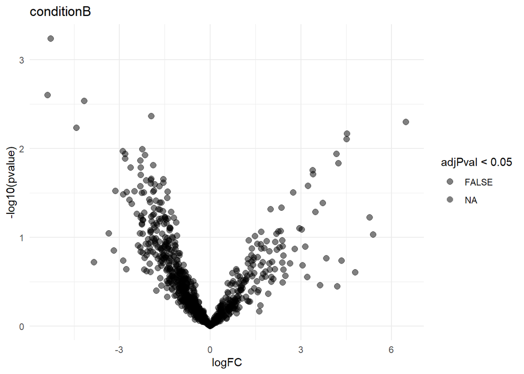

```
##
## $`conditionB + conditionB:subsety`
```

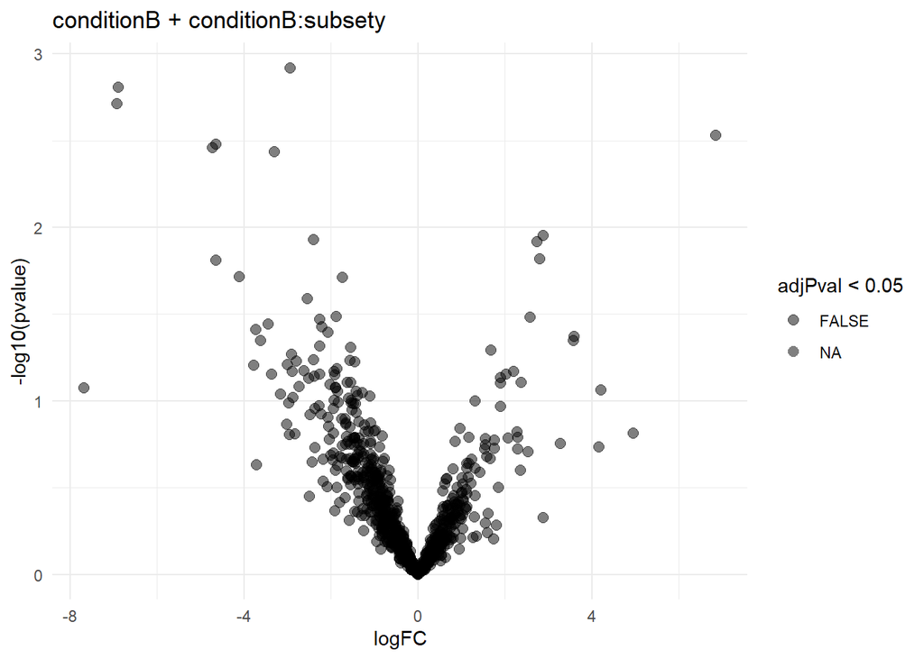

```
##
## $`conditionB:subsety`
```

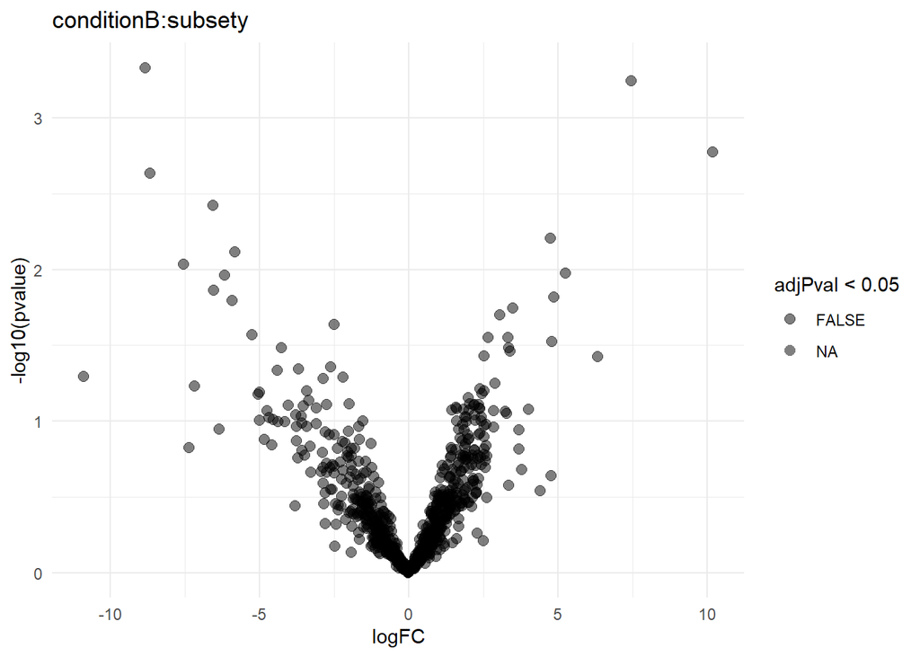

```
##
## $`conditionB + 0.5 * conditionB:subsety`
```

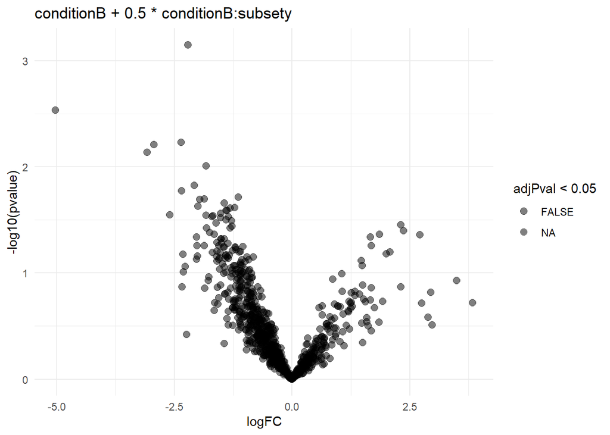

```r
volcano <- list()
for (contrast in contrasts){
volcano[[contrast]] <- rowData(pe[["pepformRel"]])[[contrast]]%>%
            ggplot(aes(x = logFC, y = -log10(pval),
                   color = adjPval < 0.05,
                   annotation=rowData(pe[["pepformRel"]])[,3])) +
  geom_point(cex = 2.5) +
  scale_color_manual(values = alpha(c("black", "red"), 0.5)) +
  theme_minimal() +
  ylab("-log10(pvalue)") +
  ggtitle(contrast)
}
volcano
```

### 3.1.2 Significant peptidoforms for each contrast

```r
tables <- list()
for (contrast in contrasts){
sigTable <- rowData(pe[["pepformRel"]])[[contrast]]
#rownames(sigTable) <-  paste(rowData(pe[["peptidoformNorm"]])[,1], rowData(pe[["peptidoformNorm"]])[,2], rowData(pe[["peptidoformNorm"]])[,3],1:nrow(pe[["peptidoformNorm"]]),sep="_")
if(nrow(sigTable %>%
  na.exclude %>%
  filter(adjPval<0.05)) > 0){
sigTable <- sigTable %>%
  na.exclude %>%
  filter(adjPval<0.05) %>%
  arrange(pval) %>%
  mutate(
    se = format(se, digits = 2),
    df = format(df, digits =2),
    t = format(t, digits = 2),
    adjPval = format(adjPval, digits = 3),
    rank = 1:length(logFC)
  )
sigTable_print <- sigTable %>% mutate(peptidoform = rownames(sigTable)) %>% gt() %>% tab_header(title = md(contrast))
tables[[contrast]] <- sigTable
#knitr::kable(sigTable, caption = contrast)
}
}
knitr::kable(tables)
```

We here find all significant peptidoforms per contrast in a table. The peptidoforms are sorted based on the adjusted pvalues We can save these tables to our computer. In this case, we find no significant peptidoforms for this dataset

# 4 DPTM

## 4.1 ptm summarisation

In this step we will summarise the peptidoform level data to ptm level data.

### 4.1.1 Get location of modification in protein (optional)

For this we need the location information of each modification in the protein. When this information is not provided, but we do have the fasta file, we can add this information ourselves.

Use this function carefully when not using MaxQuant data. Ideally, the location should already have been provided in the input file. In that case, this step can be skipped.

```r
fasta <- "human.fasta"
parsed_fasta <- read.fasta(file = fasta, seqtype = "AA", as.string = T)
```

```r
rowData(pe[["pepformRel"]])$modified_sequence <- gsub("_", "", rowData(pe[["pepformRel"]])$Modified.sequence)
```

```r
get_ptm_location <- function(feature, data, fasta, mod_column = "Modifications",
                             peptide_seq_column = "Sequence", mod_seq_column = "modified_sequence",
                             protein_column = "Leading.razor.protein", split = ",", collapse = ", "){
  prot <- data[feature,][[protein_column]]
  pep_seq <- data[feature,][[peptide_seq_column]]
  mod_seq <- data[feature,][[mod_seq_column]]
  prot_seq <- fasta[[prot]][1]

  #find location of peptide in protein
  #add -1 here, so that the addition of the location later on is correct
  pep_location <- unlist(lapply(gregexpr(pattern = pep_seq, prot_seq), min)) - 1
  final_mod <- c()
  j <- mod_seq
  #go over the modifications inside the modified sequence
  for(mod in regmatches(mod_seq, gregexpr("\\(.*?\\)\\)", mod_seq, perl=T))[[1]]){
    #find location of modification in peptide
    mod_location <- unlist(lapply(gregexpr(pattern = mod, j, fixed = T), min))
    #get location in protein (-1 because else it gives you the location after because of the presence of the modification in the string)
    location <- mod_location + pep_location -1
    #add location to modification
    mod_ <- paste(mod, location)
    #save modification
    final_mod <- c(final_mod, mod_)
    #now remove current modification from the sequence, so that we can continue to the next mod
    str_sub(j, mod_location, nchar(mod)+mod_location-1) <- ""
  }
  return(paste(final_mod, collapse = collapse))
}
```

```r
rowData(pe[["pepformRel"]])$mod <- sapply(rownames(rowData(pe[["pepformRel"]])), function(x){
    get_ptm_location(x, rowData(pe[["pepformRel"]]), parsed_fasta)
}, USE.NAMES = F)
```

### 4.1.2 Get ptm level intensity matrix

In our case, a ptm is a unique protein - modification + location combination. This could already be provided in the input file, but this is not the case here. The following code block will add this information

```r
#Add ptm variable = protein + modification
#Do this only for peptidoforms with modifications
rowData(pe[["pepformRel"]])$ptm <- ifelse(rowData(pe[["pepformRel"]])$mod != "",
                                          #if there is mod, add ptm
                                               mapply(function(x, y) {
#here, the modifications are separated in the modifications column with a comma
vector2 <- strsplit(y, ", ")[[1]]
result <- lapply(vector2, function(i) paste(x, i, sep = "-"))
final_result <- paste(unlist(result), collapse = ", ")
#input = protein column (x) and column that contains the modifications (y)
}, rowData(pe[["pepformRel"]])$Leading.razor.protein, rowData(pe[["pepformRel"]])$mod),
#else add empty string
                                               "")
```

First, we need a vector of all of these unique ptms.

```r
#Get all unique PTMs
ptms <- unique(unlist(strsplit(rowData(pe[["pepformRel"]])$ptm, split = ", ", fixed = TRUE)))
```

For every unique ptm, we take all its associated peptidoforms and aggregate all its intensity values per sample into one intensity value per sample for that ptm.

```r
#For each ptm do
ptm_x_assay <- sapply(seq(1:length(ptms)), function(i){
  x <- ptms[i]
  #Get current protein and mod from ptm
  #the separator here is the one chosen above to paste the ptms to each other,
  #or the one used in the input file in the ptm column
  prot <- str_split(x, "-", 2)[[1]][1]
  current_ptm <- str_split(x, "-", 2)[[1]][2]
  #filter on that protein and on that mod to obtain all peptidoforms that correspond to the ptm
  pe_sub <- pe[["pepformRel"]][grepl(prot, rowData(pe[["pepformRel"]])$Leading.razor.protein, fixed = T),]
  ptm_sub <- pe_sub[grepl(current_ptm, rowData(pe_sub)$mod, fixed = T),]
  #Get intensity values of those peptidoforms
  y <- assay(ptm_sub)
  #And summarise them to 1 row of intensity values: 1 value per sample for that ptm
  ptm_y <- try(MsCoreUtils::robustSummary(y), silent = T)
  if (is(ptm_y, "try-error")){
    ptm_y <- rep(NA, ncol(y))}
  ptm_y
})
#Then we get the intensity assay on ptm level
ptm_x_assay <- t(ptm_x_assay)
rownames(ptm_x_assay) <- ptms
```

### 4.1.3 Make new QFeatures object

Filter out ptms with all zero intensities or with the same intensity in every column Then add the newly made assay to the existing pe, filling out its rowData and colData

```r
print(paste(nrow(ptm_x_assay), "ptms before filtering"))
```

```
## [1] "357 ptms before filtering"
```

```r
filtering <- (rowSums(ptm_x_assay != 0, na.rm=TRUE)) > 0 &
  (rowSds(ptm_x_assay, na.rm=TRUE) > 1e-4) &
          (rowSums(is.na(ptm_x_assay)) < (ncol(ptm_x_assay)-1))
ptm_x_assay <- ptm_x_assay[filtering,]
print(paste(nrow(ptm_x_assay), "ptms after filtering"))
```

```
## [1] "357 ptms after filtering"
```

```r
all(rownames(colData(pe)) == colnames(ptm_x_assay))
```

```
## [1] TRUE
```

```r
rowdata <- data.frame(ptm = rownames(ptm_x_assay))
rowdata$Protein_Family <- sapply(str_split(rowdata$ptm, pattern="_"),function(x) x[1])
ptm_y_assay <- SummarizedExperiment(assays=as.matrix(ptm_x_assay), rowData=rowdata, colData=colData(pe))
```

```r
pe <- addAssay(pe, ptm_y_assay, "ptmRel")
```

## 4.2 Hypothesistest for each contrast

We again model our data and assess the same contrasts as for the peptidoform analysis.

```r
pe <- msqrob2::msqrob(object = pe, i = "ptmRel", formula = ~condition*subset, robust=TRUE, overwrite = T)
```

[output not shown]

[output not shown]

[output cut: 241 more lines]

[output not shown]

[output not shown]

[output cut: 97 more lines]

[output not shown]

[output not shown]

[output cut: 10 more lines]

[output not shown]

```r
rowData(pe[["ptmRel"]])$msqrobModels[[3]] %>%
                  getCoef
```

```
##        (Intercept)         conditionB            subsety conditionB:subsety
##          4.0530937         -0.4843422         -0.4803289         -0.1340573
```

```r
contrasts <- c("conditionB", "conditionB + conditionB:subsety", "conditionB:subsety", "conditionB + 0.5 * conditionB:subsety")
L <- makeContrast(c("conditionB = 0",
                    "conditionB + conditionB:subsety = 0",
                    "conditionB:subsety = 0",
                    "conditionB + 0.5 * conditionB:subsety = 0"),
                  parameterNames = rowData(pe[["ptmRel"]])$msqrobModels[[3]] %>%
                  getCoef %>%
                  names)
pe <- hypothesisTest(object = pe, i = "ptmRel", contrast = L, overwrite = T)
```

### 4.2.1 Volcanoplot

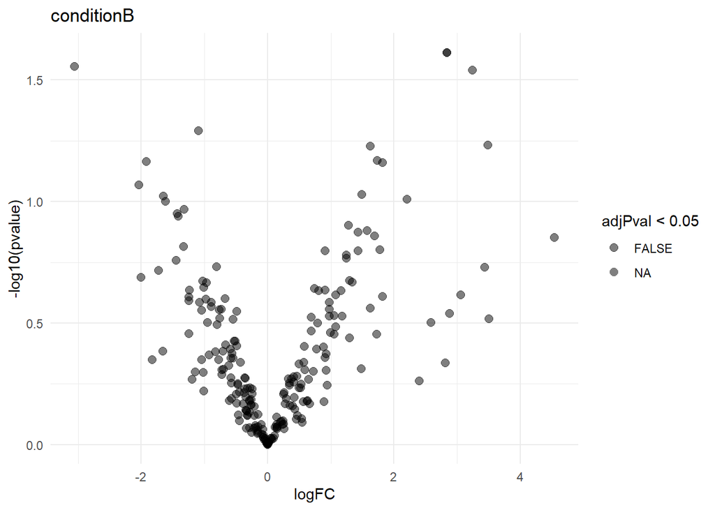

```
##
## $`conditionB + conditionB:subsety`
```

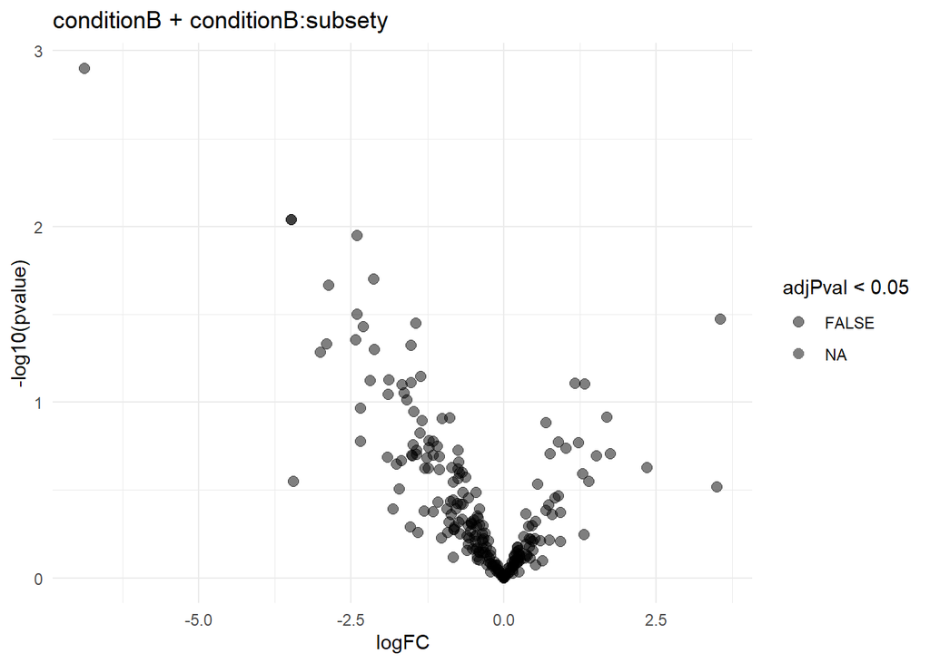

```
##
## $`conditionB:subsety`
```

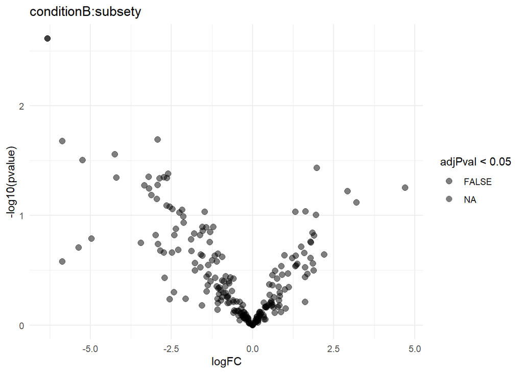

```
##
## $`conditionB + 0.5 * conditionB:subsety`
```

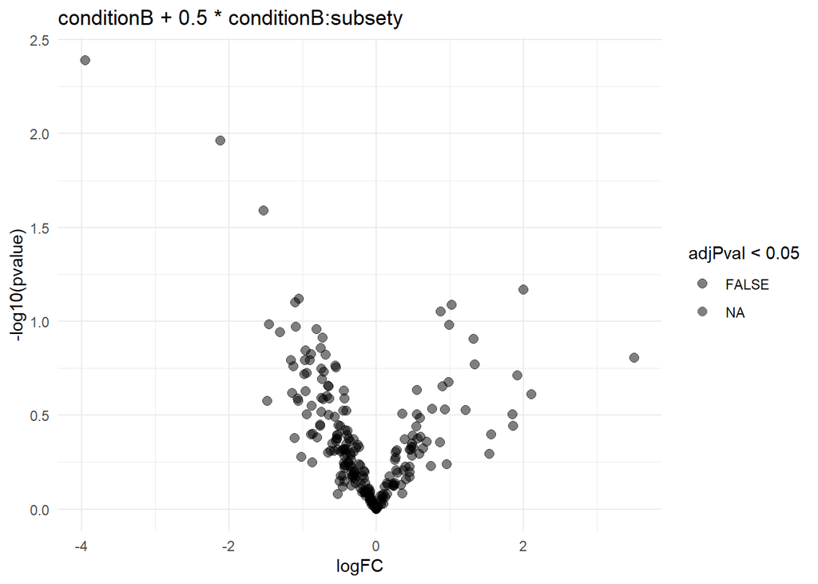

```r
volcanos <- list()
for (contrast in contrasts){
library(plotly)
volcanos[[contrast]] <-
  rowData(pe[["ptmRel"]])[[contrast]]%>%
  ggplot(aes(x = logFC, y = -log10(pval),
             color = adjPval < 0.05,
             annotation=rowData(pe[["ptmRel"]])[,3])) +
  geom_point(cex = 2.5) +
  scale_color_manual(values = alpha(c("black", "red"), 0.5)) + theme_minimal() +
  ylab("-log10(pvalue)") +
  ggtitle(contrast)
}
volcanos
```

### 4.2.2 Significant ptms for each contrast

```r
tables <- list()
for (contrast in contrasts){
sigTable <- rowData(pe[["ptmRel"]])[[contrast]]
if(nrow(sigTable %>%
  na.exclude %>%
  filter(adjPval<0.05))>0){
sigTable <- sigTable %>%
  na.exclude %>%
  filter(adjPval<0.05) %>%
  arrange(pval) %>%
  mutate(
    se = format(se, digits = 2),
    df = format(df, digits =2),
    t = format(t, digits = 2),
    adjPval = format(adjPval, digits = 3),
    rank = 1:length(logFC)
  )
sigTable_print <- sigTable %>% mutate(peptidoform = rownames(sigTable)) %>% gt() %>% tab_header(title = md(contrast))
tables[[contrast]] <- sigTable
}
}
knitr::kable(tables)
```

## 4.3 Lineplots

#### 4.3.0.1 PTM - level

```r
rownames(assay(prot[["proteinLog"]], withDimnames = F)) <- rowData(prot[["proteinLog"]])$Leading.razor.protein
rowData(pe[["peptidoformLog"]])$modified_sequence <- gsub("_", "", rowData(pe[["peptidoformLog"]])$Modified.sequence)

rowData(pe[["peptidoformLog"]])$mod <- sapply(rownames(rowData(pe[["peptidoformLog"]])), function(x){
    get_ptm_location(x, rowData(pe[["peptidoformLog"]]), parsed_fasta)
}, USE.NAMES = F)
```

```
## $`sp|O00461|GOLI4_HUMAN-(Phospho (STY)) 583`
```

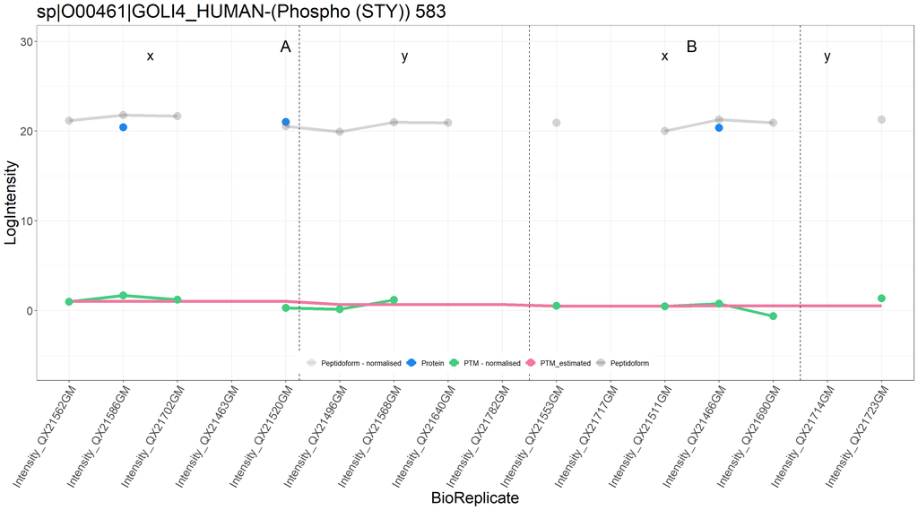

```
##
## $`sp|O14791|APOL1_HUMAN-(Phospho (STY)) 311`
```

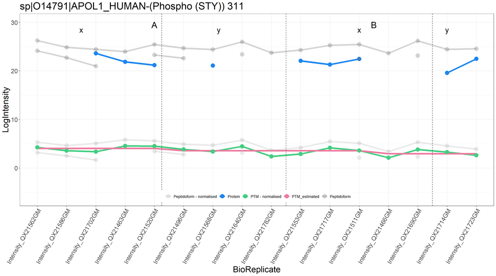

```
##
## $`sp|O14791|APOL1_HUMAN-(Phospho (STY)) 314`
```

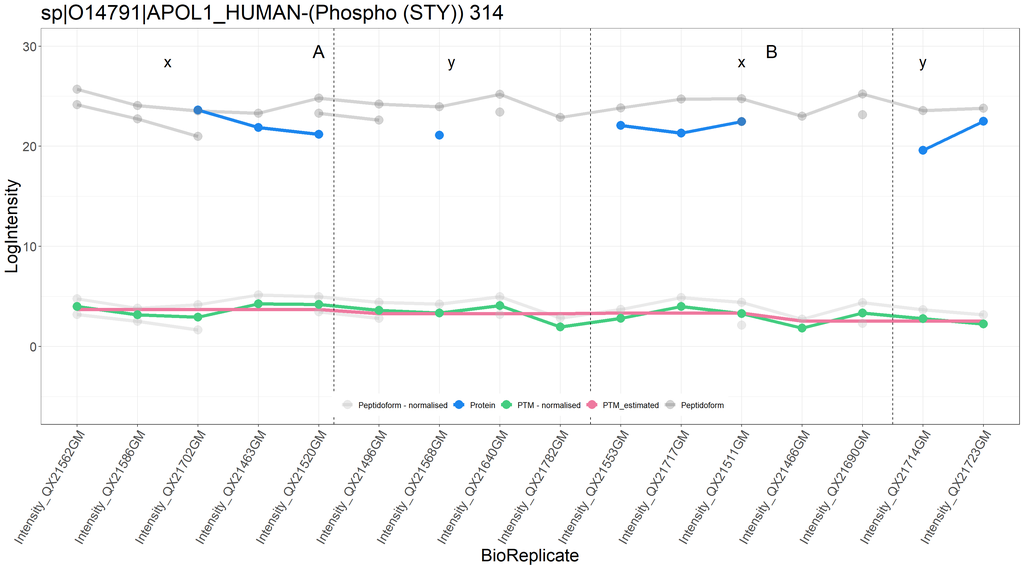

```
##
## $`sp|O43505|B4GA1_HUMAN-(Phospho (STY)) 247`
```

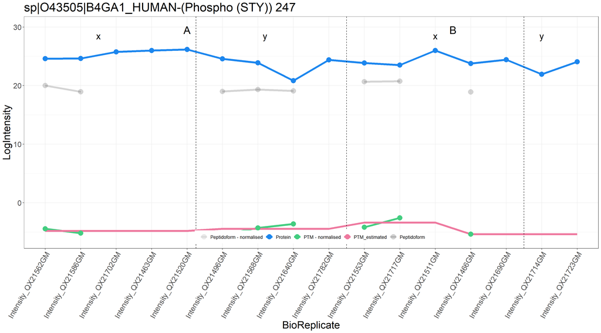

```
##
## $`sp|O60279|SUSD5_HUMAN-(Phospho (STY)) 227`
```

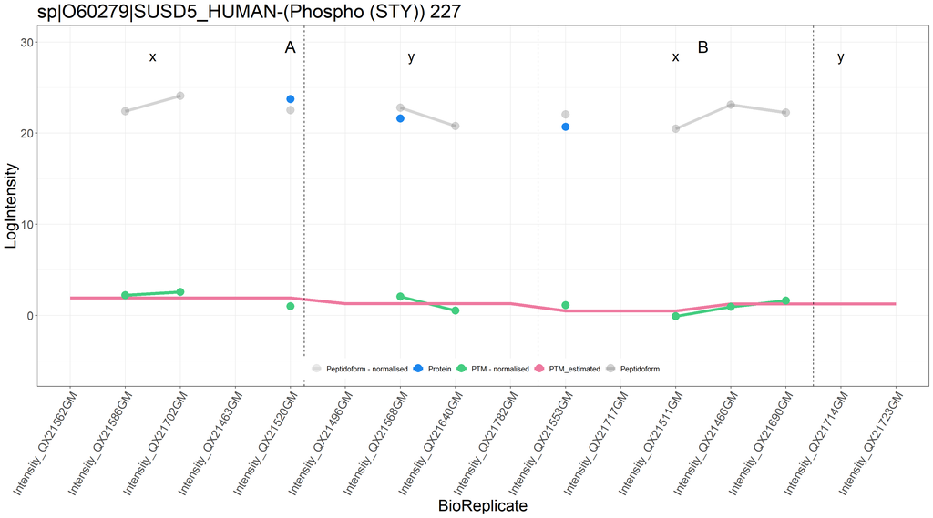

```
##
## $`sp|O60279|SUSD5_HUMAN-(Phospho (STY)) 105`
```

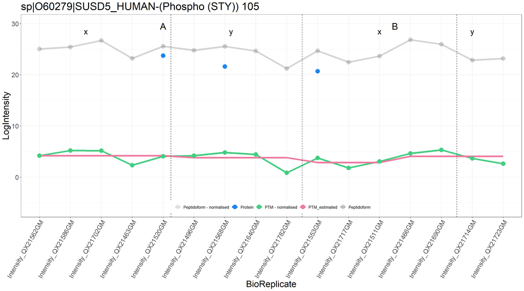

```
##
## $`sp|O60279|SUSD5_HUMAN-(Phospho (STY)) 325`
```

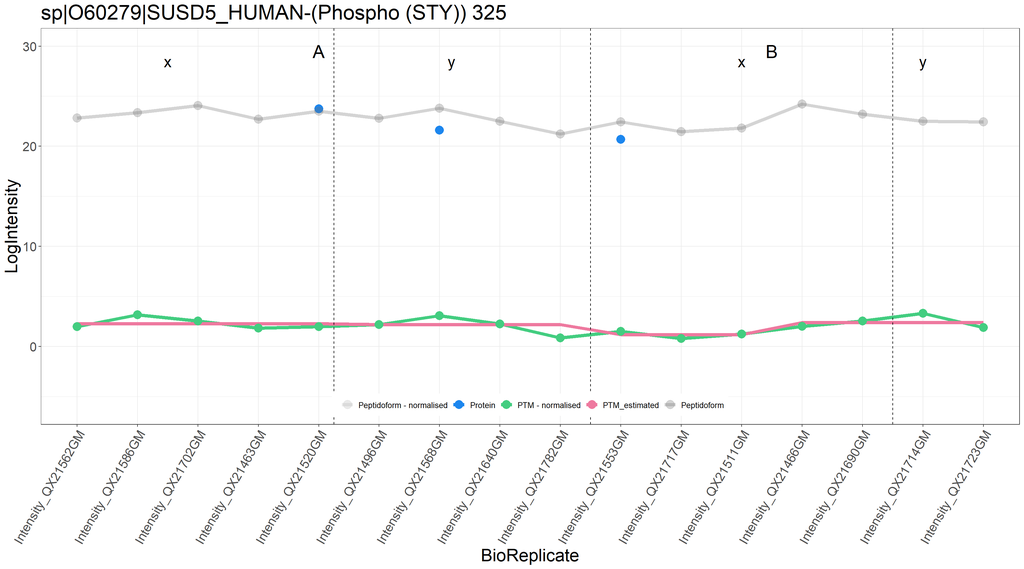

```
##
## $`sp|O60279|SUSD5_HUMAN-(Phospho (STY)) 240`
```

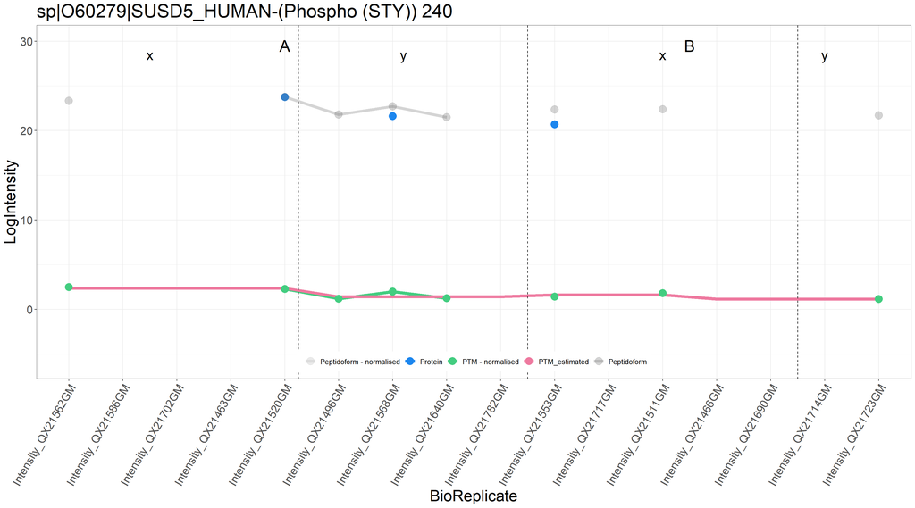

```
##
## $`sp|O94769|ECM2_HUMAN-(Phospho (STY)) 245`
```

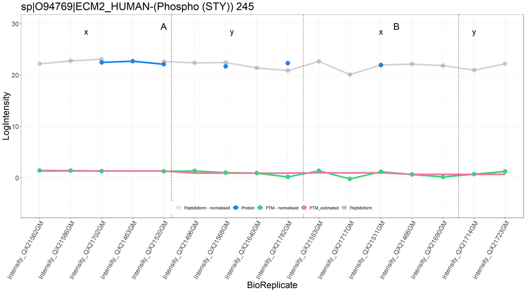

```
##
## $`sp|P00747|PLMN_HUMAN-(Phospho (STY)) 358`
```

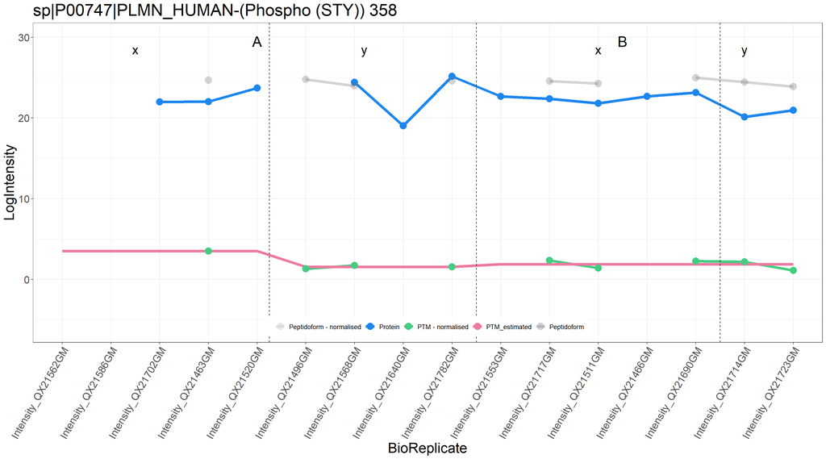

```r
#choose ptms of which you want to make lineplots
ptm_list1 <- rowData(pe[["ptmRel"]])[["conditionB"]] %>% as.data.frame %>%
  arrange(adjPval) %>% head(10) %>% rownames

plots <- list()

for (i in ptm_list1){
  #split is the separator between protein and mod in ptm column again
prot_ = str_split(i, "-")[[1]][1]
site_ = str_split_fixed(i, "-", 2)[,2]

#Protein family sequence abundance
protein <- assay(prot[["proteinLog"]], withDimnames = F)[prot_,] %>% as.data.frame()
colnames(protein) <- "LogIntensities"
protein <- protein %>%
  rownames_to_column("run") %>%
  mutate(sequence = prot_,
         FeatureType = "Protein",
         condition = colData(prot)[run,]$condition,
         subset = colData(prot)[run,]$subset) %>%
         arrange(condition, subset)

#Peptidoform abundance
pepforms <- rowData(pe[["peptidoformLog"]]) %>% as.data.frame() %>%
    filter(grepl(site_, mod, fixed=T),
           Leading.razor.protein == prot_) %>% rownames
pepform <- assay(pe[["peptidoformLog"]])[pepforms,] %>% as.data.frame()
if (length(pepforms)==0) {next}
if (length(pepforms)>1){
  pepform <- pepform %>% rownames_to_column("sequence") %>%
    pivot_longer(cols = colnames(pepform), names_to = "run",
                 values_to = "LogIntensities")
} else{
    colnames(pepform) <- "LogIntensities"
    pepform <- pepform %>% rownames_to_column("run") %>%
               mutate(sequence = pepforms)
  }
  pepform <- pepform %>%  mutate(subset = colData(pe)[run,]$subset,
         condition = colData(pe)[run,]$condition,
         FeatureType = "Peptidoform") %>%
         arrange(condition, subset)



#Peptidoform abundance - normalised
pepforms <- rowData(pe[["pepformRel"]]) %>% as.data.frame() %>%
    filter(grepl(i, ptm, fixed=T)) %>% rownames
pepform_norm <- assay(pe[["pepformRel"]])[pepforms,] %>% as.data.frame()
if (length(pepforms)>1){
  pepform_norm <- pepform_norm %>% rownames_to_column("sequence") %>%
    pivot_longer(cols = colnames(pepform_norm), names_to = "run",
                 values_to = "LogIntensities")
} else{
    colnames(pepform_norm) <- "LogIntensities"
    pepform_norm <- pepform_norm %>% rownames_to_column("run") %>%
               mutate(sequence = pepforms)
}
    pepform_norm <- pepform_norm %>%  mutate(
         condition = colData(pe)[run,]$condition,
         subset = colData(pe)[run,]$subset,
         FeatureType = "Peptidoform - normalised",
         sequence = paste(sequence, "norm")) %>%
         arrange(condition, subset)


#Normalised PTM abundance
ptm_df <- assay(pe[["ptmRel"]])[i,] %>% as.data.frame()
colnames(ptm_df) <- "LogIntensities"
ptm_df <- ptm_df %>%
  rownames_to_column("run") %>%
  mutate(sequence = i,
         FeatureType = "PTM - normalised",
         condition = colData(pe)[run,]$condition,
         subset = colData(pe)[run,]$subset) %>%
         arrange(condition, subset)


#PTM estimated
sequence <- paste(rep(i, nrow(ptm_df)), "estimate")
ptm_estimate <- tibble(sequence)
ptm_estimate$run <- ptm_df$run
protein$run <- ptm_df$run
ptm_estimate$subset <- ptm_df$subset
ptm_estimate$condition <- ptm_df$condition
ptm_estimate$FeatureType <- "PTM_estimated"
ptm_estimate$LogIntensities <- NA

fixeffects <- rowData(pe[["ptmRel"]])$msqrobModels[[i]] %>% getCoef
ptm_estimate[ptm_estimate$condition=="A"&(ptm_estimate$subset=="x"),]$LogIntensities <-
                                                    fixeffects[["(Intercept)"]]
ptm_estimate[ptm_estimate$condition=="A"&(ptm_estimate$subset=="y"),]$LogIntensities <-
   fixeffects[["(Intercept)"]] + fixeffects[["subsety"]]
ptm_estimate[ptm_estimate$condition=="B"&(ptm_estimate$subset=="x"),]$LogIntensities <-
   fixeffects[["(Intercept)"]] + fixeffects[["conditionB"]]
ptm_estimate[ptm_estimate$condition=="B"&(ptm_estimate$subset=="y"),]$LogIntensities <-
   fixeffects[["(Intercept)"]] + fixeffects[["conditionB"]] + fixeffects[["conditionB:subsety"]] + fixeffects[["subsety"]]

ptm_estimate <- ptm_estimate %>% arrange(condition, subset)

plot_df <- rbindlist(list(protein, pepform, pepform_norm, ptm_df, ptm_estimate), fill = TRUE)
plot_df$run <- forcats::fct_inorder(plot_df$run)
plot_points <- plot_df %>% filter(FeatureType != "PTM_estimated")

#plot_df[plot_df$FeatureType == 'Model'][['FeatureType']] <- "PTM Summarized"
#plot_df[plot_df$FeatureType == 'Peptide'][['FeatureType']] <- "PTM Feature"

p1 <- plot_df %>% ggplot() +
  geom_line(aes(x = run, y = LogIntensities , group = sequence, color = FeatureType, alpha = FeatureType), size =2) +
  geom_point(data = plot_points, aes(x = run, y = LogIntensities , group = sequence, color = FeatureType, alpha = FeatureType), size = 5) +
  geom_vline(data=data.frame(x = c(5.25, 9.5, 14.5)),
             aes(xintercept=as.numeric(x)), linetype = "dashed") +
  scale_colour_manual(values = c("Peptidoform - normalised" = "gray72",
                                 "Protein" = "dodgerblue2", "PTM - normalised" = "seagreen3",
                                 "PTM_estimated" = "palevioletred2", "Peptidoform" = "gray44"))  +
  scale_alpha_manual(values = c("Peptidoform - normalised" = 0.3,
                                 "Protein" = 1, "PTM - normalised" = 1,
                                 "PTM_estimated" = 1, "Peptidoform" = 0.3)) +
  #scale_size_manual(values = c(1, 2)) +
  labs(title = i, x = "BioReplicate", y = "LogIntensity") +
  theme_bw() +
  theme(axis.text.x = element_text(angle = 60, hjust=1, size = 16),
        axis.text.y = element_text(size = 16),
        legend.text=element_text(size=10),
        axis.title.y = element_text(size = 22),
        axis.title.x = element_text(size = 22),
        title = element_text(size = 22),
        strip.text = element_text(size = 16),
        legend.title =  element_blank(),
        legend.direction = "horizontal",
        legend.position = c(0.5, 0.05)) +
  annotate("text", x = 12.5, y = 29.5, label = "B", size = 8) +
  annotate("text", x = 5, y = 29.5, label = "A", size = 8) +
  annotate("text", x = 2.5, y = 28.5, label = "x", size = 7) +
  annotate("text", x = 7.2, y = 28.5, label = "y", size = 7) +
  annotate("text", x = 12, y = 28.5, label = "x", size = 7) +
  annotate("text", x = 15, y = 28.5, label = "y", size = 7) +
  ylim(-6, 30)

plots[[i]] <- p1

}
plots
```